# FAIRsimulator

Niclas Jonsson and Joakim Nyberg

2017-04-27

```r
library(FAIRsimulator)
```

## Run a simulation

The following study will be simulated:

Three cohorts of children. The first recruited at age 0, the second at age 6 month and the third at age 12 month. There are 4 treatments in each age interval 0-6, 6-12 and 12-18 months. At age 6 and 12 months, the children are randomized to new treatments. The initial randomization probabilities are 0.25, 0.25, 0.25 and 0.25. The first treatment, SoC, will always have a probability of 0.25 while the other three treatments in each age interval will be updated based on the posterior probability of being the best treatment, as estimated based on the previous cohort in the same interval.

First we initialise the study:

```r
## Set the recrutment rate to something really fast
RecruitmentRatefunction<-function(StudyObj,Cohort) {
    return(5000) #Instantaneous randomization
}
StudyObj <- createStudy(RecruitmentFunction = RecruitmentRatefunction)
```

Then execute it:

```r
StudyObj <- AdaptiveStudy(StudyObj)
```

```
## Add cohort C-3-1 [12-13m @ rand] at study time: 0
## All (320) subjects are recruited for cohort C-3-1 [12-13m @ rand] at study time 0
## Add cohort C-2-1 [6-7m @ rand] at study time: 1
## All (320) subjects are recruited for cohort C-2-1 [6-7m @ rand] at study time 1
## Add cohort C-1-1 [0-1m @ rand] at study time: 2
## All (320) subjects are recruited for cohort C-1-1 [0-1m @ rand] at study time 2
## Cohort C-3-1 [12-13m @ rand] is completed at time: 180
## Doing an analysis based on data in cohort C-3-1 [12-13m @ rand] at time 180
## [1] 0.0010 0.0999 0.3529 0.5462
## Recalculated randomization probabilities in C-3-1 [12-13m @ rand] at time 180
## [1] 0.2500000 0.0750000 0.2649399 0.4100601
## A new child cohort is created based on completed subjects from cohort C-2-1 [6-7m @ rand] at study time 181
## Cohort C-2-1 [6-7m @ rand] is completed at time: 181
## Doing an analysis based on data in cohort C-2-1 [6-7m @ rand] at time 181
## [1] 0.0075 0.0038 0.1567 0.8320
## Recalculated randomization probabilities in C-2-1 [6-7m @ rand] at time 181
## [1] 0.250000000 0.002871537 0.118413098 0.628715365
## A new child cohort is created based on completed subjects from cohort C-1-1 [0-1m @ rand] at study time 182
## Cohort C-1-1 [0-1m @ rand] is completed at time: 182
## Doing an analysis based on data in cohort C-1-1 [0-1m @ rand] at time 182
## [1] 0.0010 0.0290 0.1776 0.7924
## Recalculated randomization probabilities in C-1-1 [0-1m @ rand] at time 182
## [1] 0.25000000 0.02177177 0.13333333 0.59489489
## Cohort C-2-2 [6-7m @ rand] is completed at time: 361
## Doing an analysis based on data in cohort C-2-2 [6-7m @ rand] at time 361
## [1] 0.0000 0.4989 0.2260 0.2751
## Recalculated randomization probabilities in C-2-2 [6-7m @ rand] at time 361
## [1] 0.250000 0.374175 0.169500 0.206325
## A new child cohort is created based on completed subjects from cohort C-1-2 [0-1m @ rand] at study time 362
## Cohort C-1-2 [0-1m @ rand] is completed at time: 362
## Doing an analysis based on data in cohort C-1-2 [0-1m @ rand] at time 362
## [1] 0.0000 0.1309 0.1860 0.6831
## Recalculated randomization probabilities in C-1-2 [0-1m @ rand] at time 362
## [1] 0.250000 0.098175 0.139500 0.512325
## Updating probabilities in C-1-3 [0-1m @ rand] based on probabilities in C-2-2 [6-7m @ rand] at time: 362
## Cohort C-1-3 [0-1m @ rand] is completed at time: 542
## Doing an analysis based on data in cohort C-1-3 [0-1m @ rand] at time 542
## [1] 0.0000 0.0901 0.4044 0.5055
## Recalculated randomization probabilities in C-1-3 [0-1m @ rand] at time 542
## [1] 0.250000 0.067575 0.303300 0.379125
## Ending study simulations at study time 871
```

## Results

### Visualise the design

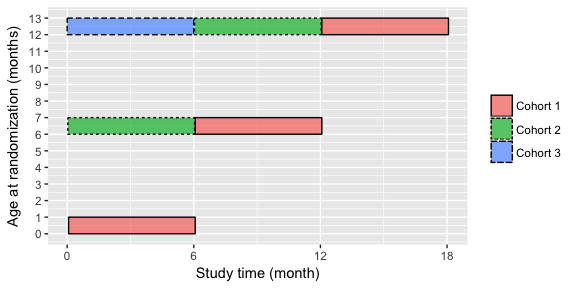

```r
plotStudyCohorts(StudyObj)
```

## Visualise the number of subjects in each cohort over time.

The number of subjects in each cohort is the result of recruitment rate, dropout and completion (i.e. being moved to the next cycle).

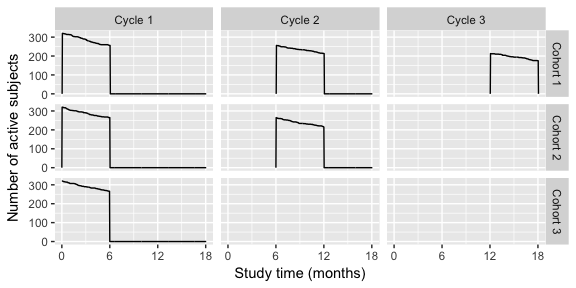

```r
plotActiveSubjects(StudyObj)
```

### Visualise the simulated HAZ data

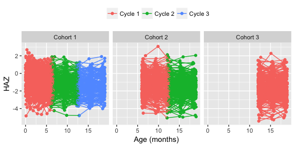

```r
plotHAZ(StudyObj)
```

### Visualise the treatment effects

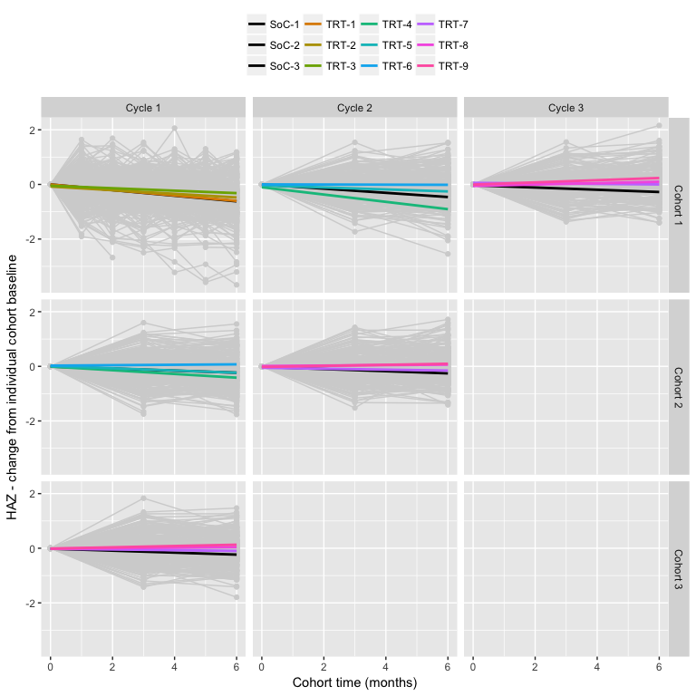

```r
plotHAZTreatmentEff(StudyObj)
```

### List the randomization probabilities

Each cohort has a set of randomization probabilities. When subjects move to later cycles, they get assigned to new treatments according to probabilities that have been updated based on the previous cohort in the same age range. The randomization probabilities can be listed:

```r
kable(StudyObj$CohortList %listmap% "RandomizationProbabilities",digits = 2)
```

| C-3-1 [12-13m @ rand] | C-2-1 [6-7m @ rand] | C-1-1 [0-1m @ rand] | C-2-2 [6-7m @ rand] | C-1-2 [0-1m @ rand] | C-1-3 [0-1m @ rand] |
| --- | --- | --- | --- | --- | --- |
| 0.25 | 0.25 | 0.25 | 0.25 | 0.25 | 0.25 |
| 0.25 | 0.25 | 0.25 | 0.08 | 0.00 | 0.37 |
| 0.25 | 0.25 | 0.25 | 0.26 | 0.12 | 0.17 |
| 0.25 | 0.25 | 0.25 | 0.41 | 0.63 | 0.21 |

### List the updated randomization probabilities

Once a study is finished, each cohort have updated randomization probabilities. These probabilities are available even if they were never used to inform the randomization of treatments in other cohorts. For example Cohort 1 in Cycle 3 will not inform the randomization in any other cohorts, since there are no cohorts following it.

```r
kable(StudyObj$CohortList %listmap% "UpdateProbabilities",digits=2)
```

| C-3-1 [12-13m @ rand] | C-2-1 [6-7m @ rand] | C-1-1 [0-1m @ rand] | C-2-2 [6-7m @ rand] | C-1-2 [0-1m @ rand] | C-1-3 [0-1m @ rand] |
| --- | --- | --- | --- | --- | --- |
| 0.25 | 0.25 | 0.25 | 0.25 | 0.25 | 0.25 |
| 0.08 | 0.00 | 0.02 | 0.37 | 0.10 | 0.07 |
| 0.26 | 0.12 | 0.13 | 0.17 | 0.14 | 0.30 |
| 0.41 | 0.63 | 0.59 | 0.21 | 0.51 | 0.38 |